# Variation de la qualité de l’eau de la rivière Pokemouche sur 20 ans

Gaël Dossou

19 juin 2024

# INTRO

Les eaux des rivières ont de multiples usages pour les humains. Cette ressource naturellement est un facteur très important dans le développement territorial, elle participe au développement économique, social et environnemental. Influencer par différents indicateurs environnementaux ils affectent les propriétés et composition physico-chimique qui détermine la caractéristique et la qualité de cette eau. Généralement, elles sont destinées à servir à plusieurs fins comme diverses activités très importantes dans la vie quotidienne et des activités économiques d’un territoire, en particulier l’irrigation, l’approvisionnement en eau, la pêche et l’agriculture, etc.

Parmi les nombreux facteurs qui influences la qualité des eaux de surface dans leur ensemble deux de ces facteurs sont les vecteurs principaux des impacts liés à la qualité des eaux. On distingue la croissance démographie et l’urbanisation. Ces deux facteurs proviennent de la transformation des terres qui est la résultante de différents secteurs et facteurs liées à l’environnement, au climat et aux activités humaines. Ont à la population (la démographie), l’urbanisation, l’industrialisation, la topographie, le tourisme, les politiques d’aménagement, la construction, la migration, le changement climatique, la distance avec le littoral, etc. Tous sont des facteurs de transformation des terres et surtout des terres côtières. L’augmentation de la population à l’échelle mondiale, les facteurs de développement des zones urbaines, la concentration industrielle et le tourisme sont les éléments qui propulsent la transformation des terres primaires et naturelles. 25% des études nous démontre que les transformations des terres côtières sont à l’origines de la démographie et de l’urbanisation. 37% des études couvres l’impact de ces transformations avec précision dans treize 13 domaines. L’agriculture, l’aquaculture, la température de l’air, le stock de carbone, la sécheresse, l’écosystème, les inondations, les glissements de terrain, la température de la surface terrestre (LST) qui font 8,3% des études. 5% pour la migration et l’occupation, la population, les intrusions de la salinité et la qualité de l’eau font 3,3% des cas d’études. Tandis que 13,3% des cas étudier sont sur la cause de la transformation causé par la dégradation des écosystèmes naturels qui sont aussi à l’origine des inondations et des glissements de terrains. Ces conséquences déséquilibrent la biodiversité et engendrent l’extinctions de diverses espèces. Seulement 4% des études visent les stratégies d’adaptation face aux conséquences de transformation de ces terres {Nguyen, 2024}.

# MÉTHODES

## Description du site à l’étude:

La rivière Pokemouche est située au nord-est du Nouveau-Brunswick, dans le bassin versant de la péninsule acadienne. Elle s’étend sur une longueur d’environ 41 kilomètres avec une superficie d’environ 20,8 km². L’entourage de la région est constitué d’un mélange de zones urbaines, agricoles et naturelles. La rivière Pokemouche est généralement alimentée par les précipitations, la fonte des neiges et les eaux de ruissèlement, avec des débits saisonniers qui varient de manière très considérable. Elle traverse plusieurs terres par son étendue, notamment des zones boisées, des terres agricoles et des zones urbaines, ce qui peut impacter la qualité de l’eau. Nous avons aussi l’agriculture, l’industrie et l’urbanisation qui sont des activités dans le bassin versant qui peuvent aussi influencer la qualité de l’eau de la rivière.

AP 2024-06-19 Parler à Jean-Luc pour en savoir plus sur ce qui a guidé la sélection des stations.

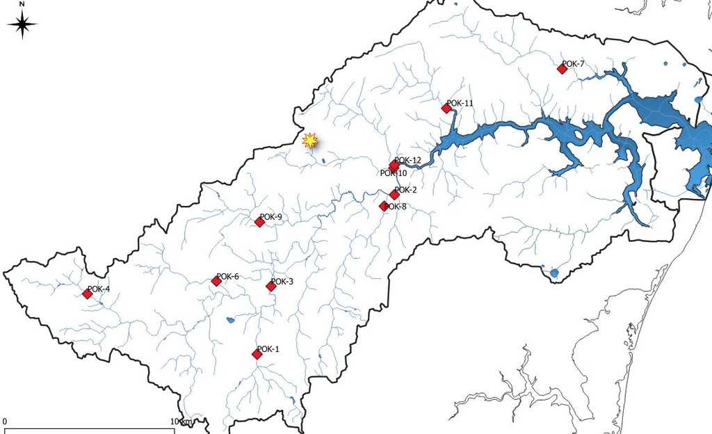

## Description de la disposition des stations

Les stations sont disposées stratégiquement, réparties de l’amont à l’aval et sur toute l’étendue de la rivière afin de permettre d’avoir une vision de la variation et de l’évolution de la qualité de l’eau sur toute sa longueur. Au total, nous disposons de 12 stations, la plupart étant situées sur les différents ruisseaux qui se déversent dans le cours d’eau de la rivière Pokemouche.

Nos données Les rivières à l’étude ont été échantillonnées quatre fois par année en 2001, 2002, 2021, 2022 en été et en automne, sur ces 12 stations soit le 1er août, le 1er septembre, le 1er octobre et le 1er novembre. Cet été 2024, nous allons collecter davantage de données liées à la composition du territoire, les données géospatiales, quelque données physico-chimique et poursser les annalyses statistiques.

**AP 2024-06-19 Expliqure au lecteur l’ordre dans lequel tu présentes les stations. Toujours suivre le même ordre pour ne pas fatiguer le lecteur.**

### Station 06 :

La station 06 est alimentée par le ruisseau Morisson, qui est d’ordre trois (03). À cette station, on note un fond sableux ; la berge est érodée et grugée par l’eau du ruisseau. Cela est souvent dû à des facteurs tels que l’écoulement, la variation saisonnière, la composition du sol, etc. La berge de la station 06 est entourée de graminées et d’arbustes. Un peu plus loin sur la berge, on peut voir des groseilles pousser, ainsi que des conifères et des épinettes.Sa largeur est de 4,3m.

La station 06 se trouve aussi dans une zone de culture de bleuetière, où un vaste territoire a été déboisé, une autre pour la culture et une autre en forêt naturelle. Sur la station six (06) avait été installé le barrage de castor et un pont construit sur la station qui sert de passage, mais qui a été détruit ainsi que le barrage. D’un autre côté, le fond là où la largeur du ruisseau se réduit, l’eau a un fond rempli de gravier. On a des dépots de particules dans le fond de notre ruisseau. On a la présence d’érosion sur la station avec une session très travaillés pour l’infrastructure routière. La surface de notre ruisseau est plainnement à lair libre.

### Station 04:

La station 04 est la tête de notre rivière et le ruisseau de cette station est d’ordre trois (03). Cette station est située dans une zone de culture de bleuetière. Tout à côté de la station, il y a une route en terre fréquentée pour accéder au site de bleuetière. Sur les berges de la station, il y a la présence de colonies de mousse (sphaigne) avec des peupliers des marais en début de floraison. Sur notre station est installé un ponceau et un îlot. La station est plus profonde que la station 06, un barrage de castor y avait été installé 9 ans en arrière, ce qui a créé de l’érosion sur la station. Le fond de la station est constitué de gravier et d’aulnes à côté. Sur la berge, on trouve des algues et de la boue, ce qui pourrait expliquer la présence d’une source à proximité. La station est humide en raison de la présence de sphaigne. Sur cette station on à des algues dans le fond de l’eau. Sa largeur est de 7m. La surface de notre ruisseau est plainnement à lair libre.

### Station 09

La station 09 est une station située au milieu d’une zone d’arbustes un peu naturelle. Elle est drainé par le ruisseau de trout qui est un ruisseau d’ordre trois (03. Juste à côté de la station, il y a une route pour piétons. Le fond de l’eau est sableux avec la berge érodée et on observe des graminées et des arbustes sur la berge. Le fond de l’eau est clair et présente une transparence à la lumière. Sur les berges ont poussé des groseilles. La surface de notre ruisseau est pleinement à l’air libre.

### Station 03:

La station 03 est drainée par un ruisseau d’ordre 05. Elle est située sur un territoire naturel modifié. Le territoire a été déboisé des dizaines d’années en arrière, ce que nous devons confirmer avec la carte cartographique. À côté de la station, il y a une route qui y donne accès et est souvent fréquentée par les voitures, les pêcheurs et autres. La berge de notre station est rocheuse avec un fond aussi rocheux (des roches difficilement altérables) et en pente. C’est un milieu pleinement inondable qui est submergé d’aulnes et absence de ponceau. Il y a aussi la présence de tonneaux et l’apport d’eau souterraine. Sur la station, on observe aussi les ligneux qui sont en tas et le débit au niveau de la station est très fort et bien plus profond que les autres stations. La zone de cette station contien des habitat non loins avec des fermes de boeuf

### Station 01:

La station 01 est une station d’ordre 04 alimenté par le ruisseau de haute bouche sud. Directement située à côté d’une grande route de bitume. La station est alimentée par un ruisseau d’ordre quatre (04). Elle est située en bordure d’un milieu forestier, où on voit des épinettes, des sapins et des bouleaux. L’eau de la station n’est pas transparente, le fond est vaseux et peu profond. Le fond est aussi sableux avec des roches et des algues. Sur les berges, de petits arbustes et ensuite des roches (facilement dégradables) qui séparent la station de la route. Deux ponceaux de deux mètres de diamètre y sont installés. La surface de l’eau est couverte par le feuillage et est à l’ombre de la lumière sur un côté et la bordure forestière qui se trouve du côté droit de la station. Une deuxième partie de la station est à ciel ouvert. L’entourage est dominé par les aulnes et semble être une plaine humide.

### Station 08:

La station 08 est une station drainée par le ruisseau Swell, qui est un ruisseau d’ordre trois (03). La station a été déboisée en 2022 et 2024. Cette station a son ruisseau à ciel ouvert, complètement exposé à la lumière. Elle est située aussi à côté d’une grande route de bitume avec une pente en pic de la route vers la station. Elle se retrouve au centre des arbustes pleins sur un côté et déboisé sur un deuxième côté. On y retrouve des bouleaux, des conifères, etc. Il est observé plusieurs débris ligneux très peu dégradés. Un milieu découvert sans végétation couvrante et présence des aulnes. Présence d’un seul ponceau. Le fond de cette station est très vaseux.

### Station 02:

La station 02 est une station située à côté d’un pont pour piétons et cyclistes. Elle est drainée par le ruisseau Suggary et est un ruisseau d’ordre trois (03). La berge de la station est constituée de graminées, de bétulacées et de conifères. À proximité, il y a un chemin de terre qui a été aménagé pour les voitures. Un petit habitat à côté et un peu plus loin la grande route. Sur la station, il y a un ponceau d’environ deux (02) mètres de diamètre, le fond de cette station est sableux et étirant avec des algues dans le fond. Sur le site, on a une grosse averse, sur un côté, on a un versant plus à pic qui se verse directement dans le ruisseau. Autour, un territoire rempli de petits arbres et sur le côté de la pente du ruisseau, des arbres plus fréquents.

### Station 05 :

La station 05 est aussi située sur un ruisseau d’ordre 03 et drainée par le ruisseau McConnell. La station se trouve sur le sentier de VTT, un territoire fréquenté à pied ou à vélo. Elle est située à côté d’un pont en métal qui n’influence pas fortement la station. C’est une station complètement à ciel ouvert. Les berges sont entourées de petits arbustes avec moins de sable sur elles à cause du niveau de l’eau qui est plus haut. Sur cette station, on y trouve un pont en bois qui n’influence pas le milieu et l’écoulement de l’eau. On enregistre une dominance des aulnes, des graminées. Cette station est en plaine inondable. Sur la berge, on y trouve des bouleaux et des épinettes. Sur la station, le courant d’eau semble très faible où on rencontre une différence pour déterminer l’amont et l’aval. Présence des algues dans le fond de l’eau.

### Station 07:

La station 07 est une station drainée par le ruisseau Waegh, qui est un ruisseau d’ordre trois (03). La station est à ciel ouvert et située à côté d’un pont en bois juste pour piétons. Dans le fond de l’eau, on observe la présence de plantes qui poussent en hiver sur l’eau. On a aussi la présence de grenouilles sur les lieux. La station 07 se trouve sur un territoire fortement aménagé et dont l’eau est canalisée de manière naturelle. L’eau est transparente et laisse passer la lumière. L’écoulement est normal à vue d’œil et sur les sites, on a une installation de ferme de porcs un peu plus loin. La nature présente des arbustes sur un côté de la station, les berges sont bien solides et le fond de l’eau aussi avec des graviers dans le fond de l’eau. La station est loin des routes et un peu sur un endroit très fréquenté par les humains et les pêcheurs.

### Station 11:

La station 11 est une station drainée par le ruisseau Maltempec, qui est un ruisseau d’ordre trois (03). Elle est située en plein milieu de la forêt, un peu loin des routes et des infrastructures. Tout autour de la station, on voit des arbustes. Sur les berges, on remarque des débris d’arbres et de bois. L’eau de la station n’est pas profonde, le fond est sableux. Sur le site, il y a des plantes aquatiques, un ancien barrage y était installé, le tributaire de Maltempète se trouve à 100 mètres de la station. La station est à ciel dégagé. Un peu plus loin, on a des résidences, des forêts naturelles très naturelles loin des infrastructures.

### Station 10:

La station 10 est une station drainée par le ruisseau Maltempec, qui est d’ordre trois (03). L’étendue de la rivière se trouve à ciel ouvert et est située directement à côté d’une autoroute. À la station, l’eau est peu profonde avec un fond sableux et des débris au fond. Sur les berges de la station, le sol est un bas-fond, très humide et boueux. La présence de plantes des zones très humides y pousse en grande quantité. De l’autre côté de la station, il y a une forêt, et elle présente une configuration d’une plaine du côté de la route. On observe la présence d’arbres qui poussent avec un léger débordement de branches vers la rivière.

### Station 12:

La station 12 est une station drainée par le ruisseau Dempsey, qui est d’ordre trois (03). La station est très profonde, plus que toutes les autres stations étudiées. Le fond de l’eau est très vaseux et boueux. Il a tendance à s’affaisser. Elle est directement à côté d’une grande autoroute et un ponceau en béton y a été construit en 1996. Sur les berges, il y a la présence de roches qui ont été placées à cause de l’aménagement du site. La largeur du site a été estimée à environ 15 mètres car la profondeur et la densité de l’eau au fond du ruisseau sont très denses. À la surface de l’eau, on a du mal à déterminer le sens de l’écoulement de la station. L’aval du ruisseau est à ciel ouvert alors que l’amont est rempli d’arbres qui lui font de l’ombre. La végétation sur la station est déboisée. Dans le fond du ruisseau, on trouve des débris.

### station 4

la station 04 est une station situé sur un territoire vaste a coté de culture de bleuetière. un territoire vastement déboisé. La station 04 a sont cours d’eau à ciel ouvert avec une eau peu profond. Sur cette station il y à la présence des mousses, présences de gravier (une roche non dégradable) avec une présence des algues avec une berge très boueuse. ce qui la caractérise d’une station humide, absences de roche dégradable ou altérable.

### station 08

Comme la station 08 est à exposée avec le ciel, et une route à coté et des matières en dissous dans le fond. Il a aussi un fond vaseux prèsque meme caractéristique que la station 01 mais juste qu’ici la suface ou l’étendure de l’eau est petit avec une petie l’argeur et très peuprofond

### Sation 07

Elle présente le meme cas mais jusque en 2001-2002 la conductivité est très peu variable casi négligeable ce qui peut etre la cause de l’absence de route, un territoire très boisé, moin exposé au soleil, reaménagé et sans des particule ou substance dissous dans le fond. Juste une présence de pond pour piéton qui influence très peu la rivière à ce niveau.

## Cgerp et les échantillonnages réalisés

Le comité de gestion environnementale de la rivière Pokemouche a effectué les premiers échantillonnages que j’ai à ma disposition. Cette base de données est constituée de 56 paramètres étudiés, tous prélevés quatre à cinq fois chaque automne et été en 2001-2002, qui constitue une première période d’échantillonnages, et en 2021-2022, qui constitue une deuxième période. C’est sur ces données que nous allons nous appuyer pour étudier la variation de la qualité de l’eau sur une période de 20 ans, en regardant les variations inter-annuelles pour chaque période, ainsi que les variations saisonnières. Ces échantillonnages ont été effectués avec la même méthodologie à la surface de l’eau, car la rivière Pokemouche est peu profonde, soit environ un mètre de profondeur. Cela signifie que la qualité de l’eau en profondeur de la rivière sera quasiment la même qu’en surface.

## Description des paramètres physico-chimiques à l’étude

Parmi les 56 paramètres qui ont fait l’objet d’un suivi, nous allons décrire les plus importants, soit ceux qui influencent le plus la qualité de l’eau de notre rivière et dont j’aimerais étudier la variation. Ces paramètres sont répartis en trois groupes différents, dont les paramètres physico-chimiques comme la température, le pH, la turbidité (NTU), la conductivité, l’oxygène dissous, les nutriments, etc. Les paramètres biologiques, tels que les coliformes fécaux, et les métaux comme le plomb (Pb), le cadmium (Cd), le mercure (Hg), et le zinc (Zn), etc. (Bricha, S., Ounine, K., Oulkheir, S., El Haloui, N., & Attarassi, B. 2007).

### La température:

La température de l’eau est mesurée en degrés Celsius (°C) ou en degré Kelvin (K), mais dans notre étude, elle sera en degrés Celsius. Elle varie en fonction des saisons, de la profondeur à laquelle elle est mesurée, ou même de sa proximité des sources de chaleur, comme l’exposition au soleil ou même des activités humaines. La température de l’eau a un impact sur la solubilité des gaz, la croissance des organismes aquatiques, et la chimie de l’eau.

### Le pH:

Le pH mesure l’acidité ou l’alcalinité de l’eau. Nous le mesurons sur une échelle de 0 à 14, où 7 est neutre, tout pH inférieur à 7 est acide et supérieur à 7 est basique. Le pH de l’eau peut affecter la disponibilité des nutriments, la toxicité des métaux lourds, la santé des organismes aquatiques, et la disparition de certaines espèces.

### La turbidité

La turbidité consiste à mesurer la clarté de l’eau en mesurant la quantité de particules en suspension. Elle est souvent mesurée en unités de turbidité (NTU). Lorsque la turbidité est élevée, cela peut être causé par des sédiments, des particules organiques, ou des polluants, et peut affecter la transmission de la lumière à travers l’eau, la photosynthèse, et la santé des écosystèmes aquatiques.

### La conductivité:

La conductivité mesure la capacité de l’eau à conduire le courant électrique, ce qui est influencé par la présence de minéraux dissous, tels que les sels et les métaux (comme les océans). Elle est souvent mesurée en microsiemens par centimètre (µS/cm) ou en millisiemens par centimètre (ms/cm). La conductivité de l’eau peut nous permettre de savoir s’il y a présence de contaminants, et dans certains cas, nous pouvons l’utiliser comme indicateur de la salinité ou de la dureté de l’eau.

### L’oxygène dissous

L’oxygène dissous mesure la quantité d’oxygène dissous dans l’eau, nécessaire à la respiration des organismes aquatiques. Nous le mesurons en milligrammes par litre (mg/L) ou en pourcentage de saturation. Le niveau d’oxygène dissous varie en fonction de la température, de l’altitude, de la pression atmosphérique, et de la présence de matière organique ou de polluants dans l’eau.

### autreschoses

Les nutriments, tels que l’azote (sous forme de nitrate, nitrite, ammonium) et le phosphore (sous forme de phosphate), sont essentiels à la croissance des plantes aquatiques et des algues. Cependant, un excès de nutriments peut entraîner une propagation excessive d’algues, appelée eutrophisation, ce qui peut entraîner une diminution de l’oxygène dissous et des problèmes de qualité de l’eau.

### les coliformes

Les coliformes fécaux sont des bactéries qui sont généralement présentes dans les intestins des animaux (y compris les mammifères, dont les humains) et se retrouvent fréquemment dans les matières fécales. Ils sont souvent utilisés comme indicateurs de contamination fécale dans l’eau, car leur présence indique la possible présence de pathogènes d’origine fécale qui peuvent être dangereux pour la santé humaine. Les coliformes fécaux sont généralement exprimés en nombre de colonies formant unités (CFU) par 100 millilitres (ml) d’eau. Une concentration élevée de coliformes fécaux dans l’eau peut indiquer une contamination fécale récente et un risque potentiel de maladies d’origine hydrique. Cependant, il est important de noter que la présence de coliformes fécaux dans l’eau ne signifie pas nécessairement qu’elle est dangereuse pour la consommation, car d’autres facteurs, tels que le type de coliformes présents et la présence de pathogènes spécifiques, doivent être pris en compte.

### Les métaux :

Ces éléments que nous allons vous décrire sont des polluants courants dans l’eau qui peuvent avoir des effets néfastes sur la santé humaine et celle des écosystèmes aquatiques. Le Plomb (Pb) : Le plomb est l’un des métaux lourds toxiques qui affectent souvent notre système nerveux, les reins, le sang et le développement du cerveau, surtout chez les enfants. Il provient généralement de la corrosion ou de l’altération des tuyaux en plomb, des conduites d’eau et de diverses activités industrielles.

Le Cadmium (Cd) : Le cadmium est également un métal toxique qui provoque des problèmes rénaux, des troubles osseux et des dommages pulmonaires. Il est souvent associé à des activités industrielles telles que la production de batteries, l’exploitation minière et le traitement des métaux.

Le Mercure (Hg) : Le mercure est l’un des métaux lourds qui a des effets toxiques sur notre système nerveux central, les reins et le système immunitaire, entre autres. Il est souvent associé à la combustion de combustibles fossiles, à la production de chlorure de vinyle et à d’autres activités industrielles.

Le Zinc (Zn) : Le zinc est un oligo-élément essentiel à de nombreux processus biologiques, mais à des concentrations élevées dans l’eau, il devient toxique pour les organismes aquatiques. Le zinc provient de diverses sources, notamment des activités industrielles, de l’agriculture et de l’érosion des sols.

Nous mesurons ces éléments en microgrammes par litre (µg/L) conformément aux réglementations et normes strictes qui limitent les concentrations de ces métaux dans l’eau potable et les eaux de surface pour protéger la santé humaine et l’environnement. En général, tous ces paramètres sont essentiels pour évaluer la qualité de l’eau et comprendre l’état des écosystèmes aquatiques.

# RÉSULTATS ET DISCUSSION

AP 2024-06-19 Dans la description des variations, toujours essayer de suivre le même patron: 1) un énoncé ou deux sur la variabilité entre stations et entre périodes (box-plot); 2) un énoncé sur la variabilité saisonnière (graphique des campagnes); 3) un énconé sur les recommandations canadiennes; 4) un énoncé sur les valeurs obervées comparées au recommandations canadiennes.

## Température, variabilité spatiale

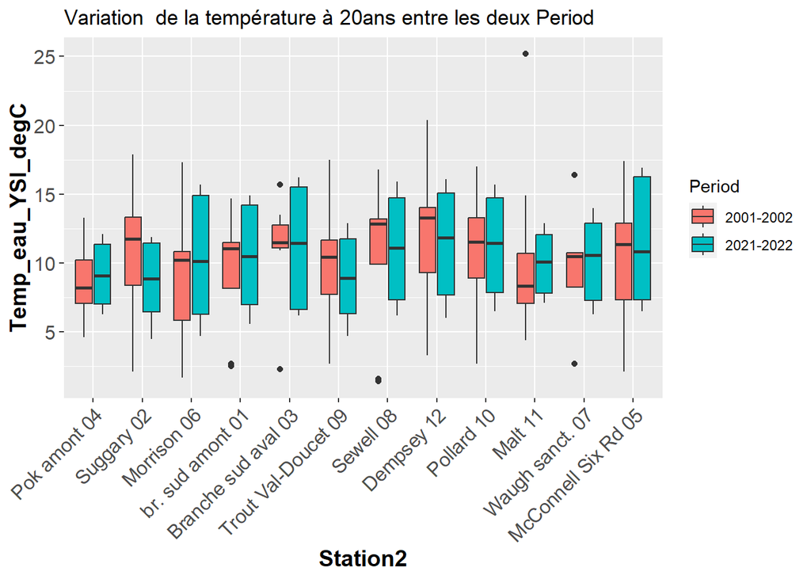

Variations de la température entre les douze stations à l’étude (présentées de l’ouest vers l’est) pour la période 1 (2001, 2002) et 2 (2021-2022)

Commentaire:

Il n’y a pas de différente systématique de température entre les deux périodes. Certaines stations ont été échantillonnées à des periodes chaudes comme la station 11 (Maltempec) et à des periodes froides comme la station 09 (Trout).

Des moustaches plus longues indiquent une plus grande variabilité dans les données.

Les moustaches son plus grande et présent sur tout les stations en 2001_2002 qu’en 2021_2022 ce qui indique une grande variabilité.

La temp a baisser sur tout les stations. la station 4 et 2 à la fin de l’été ont la plus faible temp mais c’est les stations 3 et 6 qui était parmis les plus grande temp à la fin de l’été qui on baissé et sont devenir les plus basses temp de tout les station a la fin de l’automne. en 2021 la temp est comprise entre 6 et 16 dégré. La temp sur tous les stations ont baissé de 85%

La temp a baissé sur tous les stations commes dans tout les autres années. la temp a varié entre 4 et 17 dégré. La temp sur tout les stations ont baissé de 80%

### Autre manière de voir les variations saisonnières sur quatre années:

traiter la date comme “Campagne no” (voir la création de la variable “Campagne” au début du script).

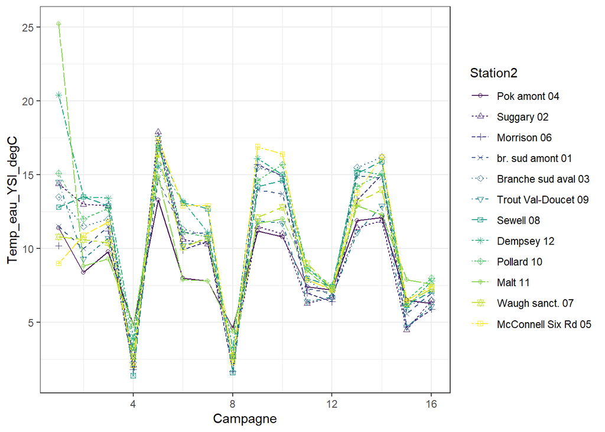

Commentaire du graphique des quatre années :

La différence de température est systématique sur les deux périodes :

La température a plus baissé le 1er novembre 2001 et 2002 que les températures du 1er novembre 2021 et 2022, et ce sur toutes les stations.

Les stations 11 (Malt) et 12 (Dempsey) ont les températures les plus élevées le 1er août 2001 et les années suivantes, la température n’a plus augmenté jusqu’à ce niveau.

La température en novembre 2001 et 2002 a baissé plus que les températures de novembre 2021 et 2022.

La station 08 (Sewell) présente la température la plus basse dans la période 01 et la station 02 (Suggary) dans la période 02.

Les températures ont baissé en pic lors de la période 01 et de manière légèrement constante dans la période 02.

Les questions auxquelles on peut répondre :

La température qui a baissé en pics lors de la période 01 a-t-elle influencé certains paramètres ? Ont-elles été causées par des facteurs météorologiques, climatiques ou des causes territoriales à prendre en compte ?

Remarque :

La station 12 est à ciel ouvert et sur un côté à un territoire déboisé et de l’autoroute, et plus on a moins d’arbres, moins on a de pluie et plus la température est élevée. Mais ce déboisement a eu lieu en 2023, qu’en est-il du territoire en 2001 ? Mais la station 11 est en plein milieu de la forêt.

## Oxygène dissous

### variabilité spatiale : Oxygène dissous

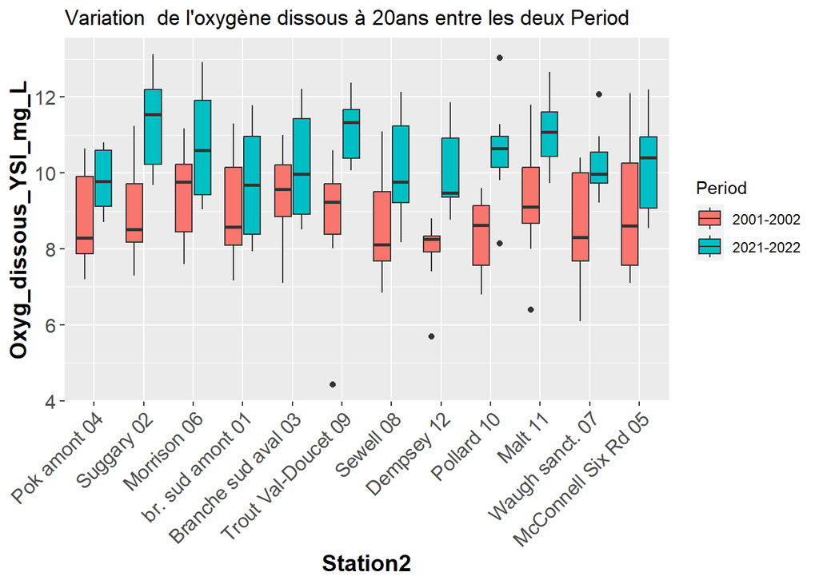

```
##    Min. 1st Qu.  Median    Mean 3rd Qu.    Max.    NA's
##   4.420   8.500   9.585   9.636  10.787  13.130       2
```

Commentaire:

La teneur en oxygène dissous de la period 2001-2002 est généralement plus basse que la teneur en oxygène dissou de la periode 2021-2022.

La norme canadienne des recommandations du CCME (Conseil canadien des ministres de l’Environnement) dit que pour:

L’eau d’une rivière, d’un ruisseau ou d’un cours d’eau en période d’été ou à une à une température normal doivent avoir une teneur en oxygène dissous de 6mg/l pour les petites espèces biologique à un niveau rudimentaire et de 5,5mg/l pour les espèces a un niveau superieur.

L’eau des montagne, situé dans les endroits en haute altitude ou en période de froid (hivernale) doivent avoir une teneur en oxygène dissous de 9,5mg/l pour les petites espèces biologique à un niveau rudimentaire et de 6,5 mg/l pour tout les autres espèces.

Nos valeur varient entre 4,420mg/l et 13,130mg/l d’oxygènes dissous sauffe quelque valeur abérente observé sur les station 09 et 12.

Dans l’ensemble, les stations ont vu leur concentration en oxygène diminuer d’environ 1-2 mg/L entre le 1er août 2001 et le 1er novembre 2001. La station 10 (Pollard) a gardé une allure presque constante (peu variable et faible), tandis que la station 02 (Suggary) a connu une baisse continue et linéaire, avec la plus faible teneur en 2001. Quant à la station 05 (M Conell), ayant la teneur la plus élevée, elle a baissé en piqué jusqu’au début de l’automne pour devenir presque constante. La teneur en oxygène dissous à varié entre 7,3mg/l et 12,1mg/l en 2001

En 2002, les variations saisonnière d’oxygène étaient synchrone entre les stations. La stations Suggary étant la plus oxygénée et la station Dempsey la moins oxygénée.

La station 09 a varié avec des baisse et hausse aigu ayant la plus faible teneur le 1er octorbre 2002. La station 06 a varié prèsque a la constance avec le plus haute teneur de meme que la station 06. Les variation saisonnière en 2002 sont comprise entre 4,42mg/L et 11,240mg/L. Ce graphique nous renseigne sur une faible teneur en oxygène en 2002 par rapport à l’an 2001, et avec une plus baisse teneur en 2001.

À tous les station on observe une hausse sur toute les saisons. 20 années après en 2021 la teneur en oxygène dissous est comprise entre 7,94mg/L et 12,14mg/L comme en 2001. À la station 10 (Pollard) on observe une grande baisse d’environs (50%) et une forte teneur à la station 02 (Sugarry) et 09 (Trout) toujours augmentant avec les plus grande teneur.

On remarque d’abord par rapport au autres années que la teneur en oxygène dissous a plus été élevé et est comprise entre 8.28mg/L et 13.13mg/L. La teneur à tous les station ont connu de faible variation prèsque linéaire, contrairement à la station 07 et 10 qui ont connu le plus de baisse (45%)et(50%) à la fin de la saison. La station 02 a la fin de la saison à la plus haute teneur et la station 06 à coté.

Commentaire:

On remarque que la variation periodique de 2021 à 2022 est comprise entre 7mg/L et plus de 13mg/L. On constat que malgré la variation saisonnière de hausse et de baisse qui se remarque sur les stations entre les deux année a augmentanter. Sur cette periode on remarque bien l’allure de la station 01 qui à connu de forte baisse et hausse avec la plus faible teneur de la periode et la station 02 avec la plis forte teneur durant la periode.

### Autre manière de voir les variations saisonnières sur quatre années:

Traiter la date comme “Campagne no” (voir la création de la variable “Campagne” au début du script).

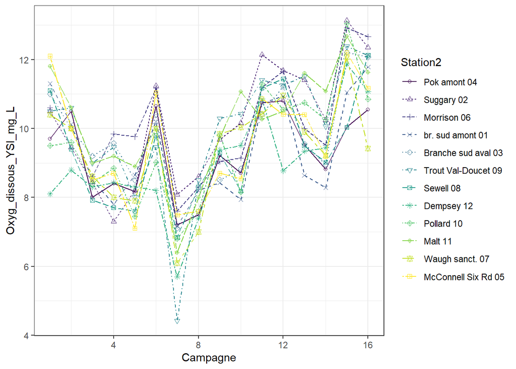

Commentaire du graphique des quatre années :

La teneur en oxygène dissous a considérablement baissé sur toutes les stations en octobre 2002. L’eau est très faiblement oxygénée sur toutes les stations en octobre 2002.

Les plus faibles teneurs en oxygène sont celles enregistrées sur la station 09 (Trout) et 12 (Dempsey).

Lors de la période 01 en 2001, la teneur en oxygène a baissé de manière synchronisée sur toutes les stations durant toutes les saisons. En 2002, lors de la période d’été, l’eau est très oxygénée sur toutes les stations et en automne, l’eau est devenue très faiblement oxygénée sur toutes les stations. Alors qu’en la deuxième période (2021-2022), la teneur en oxygène a augmenté de manière synchrone et continue sur toutes les stations et sur les deux ans.

L’eau de la station 02 (Suggary) est la plus faiblement oxygénée en novembre 2001. En octobre 2002 et durant toute la période deux, elle est l’une des stations les plus oxygénées.

La station 12 (Dempsey) présente l’allure de l’eau la moins oxygénée durant toutes les deux périodes.

Remarque :

La température a aussi baissé en novembre 2001 et 2002, cela a peut-être influencé la teneur en oxygène de cette période.

Question :

## Conductivity_microS_cm

### Conductivité variabilité spatiale

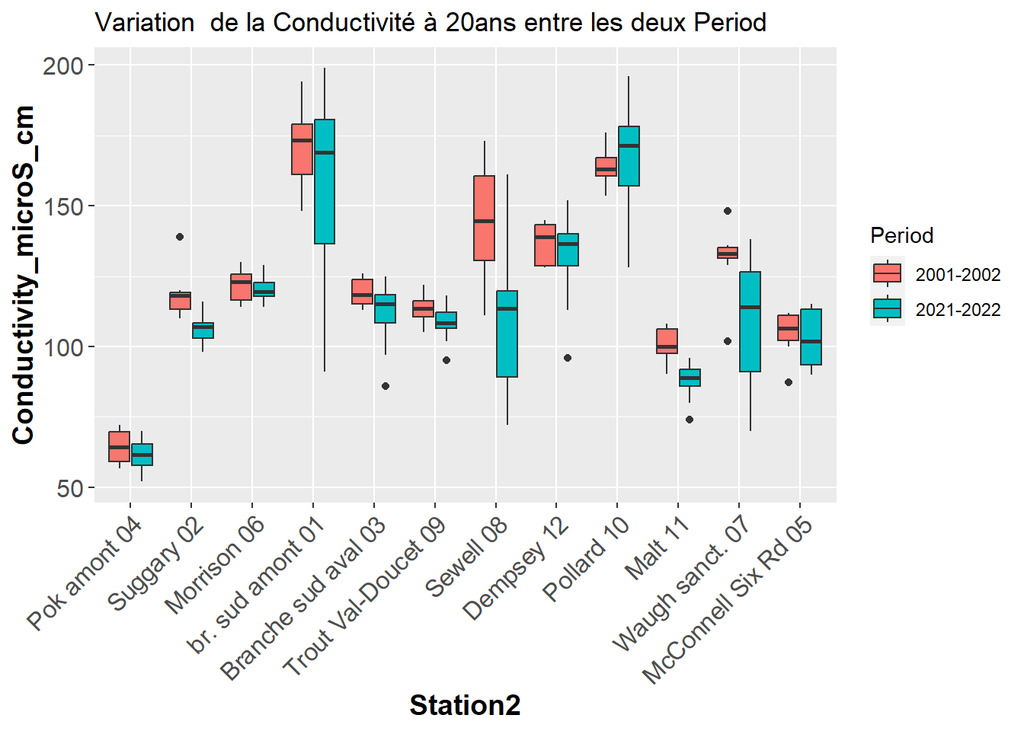

Commentaire:

La conductivité est plus élevé sur tout les stations à la période 2001-2002 de plus que la conductivité en 2021-2021, sauf sur la station 10 qui a une conductivité plus élevé en 2021-2022.

La station 4 se démarque par les valeurs de conductivités environ deux fois moins élevées qu’aux autres stations. (partie Résultats).

(interprétation), on peut dire «En effet, la station 4 est la plus reculée d’entres toutes les stations le long de la branche principale; elle est la plus éloignée de l’influence des marées… Il n’est donc pas surprenant qu’elle affiche les plus faibles valeurs de conductivité.

La conductivité présente une plus grande variabilité 20ans plus tard et ce sur les stations 01, 08 et 07.

La conductivité lors de la période 01 présente des valeurs abbérentes forte sur les station 02 et 07. mais à la période 02 ils indique des valeurs abbérente faible de la conductivité sur les stations 03, 09, 12, 11. ces valeurs nous indique soit une anomalie ou une variabilité extrème sur ces stations a ces périodes.

La conductivité n’a pas vraiment varié, ils ont baissé de (9%) à tous les stations soit une variation presque constante. La station 4 a la plus faible conductivité sur tous les prélèvements de l’an 2001. Les plus grandes conductivités sont celle de la station 01 et 10. La station 08 a augmenter de 27% en octobre pour baisser de 36.6% en novembre.

NB: si les autre son presque constant faut donc regarder ce qui se passe à la station 08.

La plus basse conductivité a été enregistré sur la sation 04 sur tout la saison d’échantillonage avec un écart d’environs 75micro Sm_cm. la conductivité à augmenté de septembre à novembre à la station une avec la plus grande conductivité. seul en sep et Oct les plus grande observation on été faites.

La conductivité a baisser à tous les stations. La station 04 à la plus basse conductivité a toutes les saisons en 2021. la conductivité à varié entre 50 micros SCM à 200 micros SCM. La station 01 et 10 ont les plus grandes conductivités, avant que la station 01 ne connaisse une grande baisse (66%).

NB: la plus faible conductivité est en 2021 ainsi que la plus grande et c’est en cette année on observe de grande variation.

La conductivité à légèrement varier, avec les courbes presque constants sauf à la station 01 et 10. sur la station 04 on à la plus faible conductivité. De la fin de l’été jusqu’en octobre la conductivité a augmenter à la station 01pour baisser de 27,3% jusqu’en novembre (NB: la plus grande variation par rapport au autre station)

Commentaire:

La conductivité de la station 4 demeure plus la plus basse. La conductivité de la station 01 a varié en baissé en 2001 pour augmenter en 2002 avec la plus grande conductivité sur toutes les stations des deux années de la période. La conductivité durant toute la période a augmenté avec de petite variation en 2001 et une augmentation continue en 2002. À la fin de l’été 2001 jusqu’en octobre et de la fin de l’été 2002 jusqu’en septembre la conductivité augmente à la station 08 pour baisser d’octorbre en novembre 2001 et de septembre en novembre 2002. (NB: voir ce qui influence la variation à cette saison .)

Commentaire:

La conductivité de la station 4 a la plus basse conductivité de la période. En générale la conductivité a plus baissé en 2021 qu’en 2022. À la fin de l’été en 2021 les conductivités sont plus haut que les conductivités à la fin de l’automne et on observe aussi une augmentation de la conductivité durant les deux saisons. Ce qui n’est pas le cas en 2022 ou la variation a augmenté à tous les stations mais casi constant sauf à la station 01 avec un grand baisse(27,3%).

### Autre manière de voir les variations saisonnières sur quatre années:

traiter la date comme “Campagne no” (voir la création de la variable

“Campagne” au début du script).

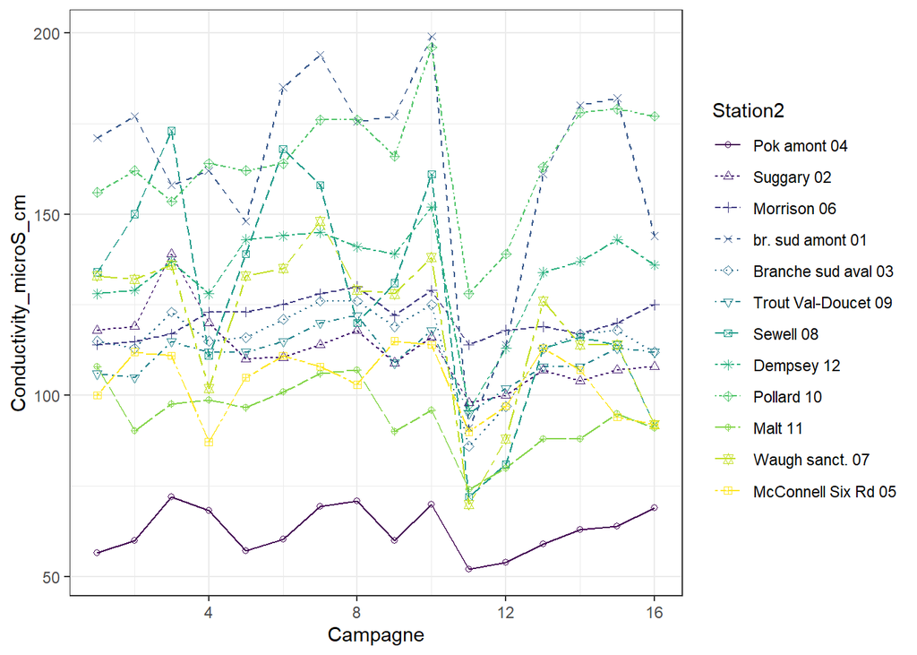

Commentaire du graphique des quatre années :

L’eau à la station 04 (La tête des stations) durant toutes les deux périodes a la plus faible conductivité.

Il y a aussi la station 11 qui présente aussi une faible conductivité par rapport aux autres stations.

Les stations 01 (Br sud amont) et 10 (Pollard) ont enregistré les plus fortes conductivités lors des périodes 01 et 02.

Question :

Remarque :

La station 04, étant la tête du ruisseau et aussi une rivière d’ordre 3, est susceptible de ne pas trop être drainée par de grands ruisseaux et aussi moins influencée par plusieurs facteurs environnementaux et territoriaux surtout car elle se retrouve en tête du ruisseau. Elle n’a pas été influencée par les facteurs territoriaux lors de l’écoulement sur le bassin.

La station 01 (Br sud amont) est un ruisseau d’ordre 4, ce qui peut influencer la conductivité de l’eau à cette station. L’eau de cette station est aussi trouble avec des matières organiques déposées dans le fond de l’eau et d’un fond très vaseux. Elle est aussi sans doute influencée par l’autoroute à côté et les roches facilement dégradables qui sont sur les berges.

## pH !!!!!!!!!!!!!!!!! À CORRIGER !!!!!!!!!!!!!!!!!!!

### pH variabilité spatiale

[figure not shown]

Commentaire:

Le pH sur les deux périodes n’ont pas beaucoup varié et cela prèsque sur tous les stations.

Le pH de la stations 08 indique une plus grande variabilité sur la période 2021-2022 par rapport au pH en 2001-2002.

le pH de la periode 01 présente une plus grand variabilité de données par rapport à la période 02.

Le pH n’a pas varié il est prèsque constant sur tout les station sauf à la station 01, 05. Le plus bas pH est observé à la station 04 sur tooute les saisons. La station 01 à le pH le plus élevé et à augmenté de fin aout en septembre pour baisser de septembre jusqu’en novembre. Le pH de la station a eu le meme allure que le pH de la station 01

Commentaire:

Le pH en 2001 à baissé avec une allure décroissante. En 2002 le pH a augmenté à la fin de l’été pour ensuite baisser jusqu’a la fin de l’automne. En 2002 certaine station ont augmenté de pH. La plus haut pH est obtenu en 2001 et le plus bas en 2002.

Commentaire:

Le pH en 2021 aaugment a la fin de l’été pour en suite baissé et augmenté à la fin de l’automne sauf le cas de la station 08 qui baisse de la fin de l’été jusqu’en octobre pour augmenté à la fin de l’automne. En 2022 l’éffet est contraire qu’en 2021, le pH augment de la fin de l’été jusqu’au 1er septembre pour baisséjusqu’à la fin de l’automne sauf à la station 04 ou deja depuis la fin de l’été le pH baisse jusqu’a la fin de l’automne.

### Autre manière de voir les variations saisonnières sur quatre années:

traiter la date comme “Campagne no” (voir la création de la variable “Campagne” au début du script).

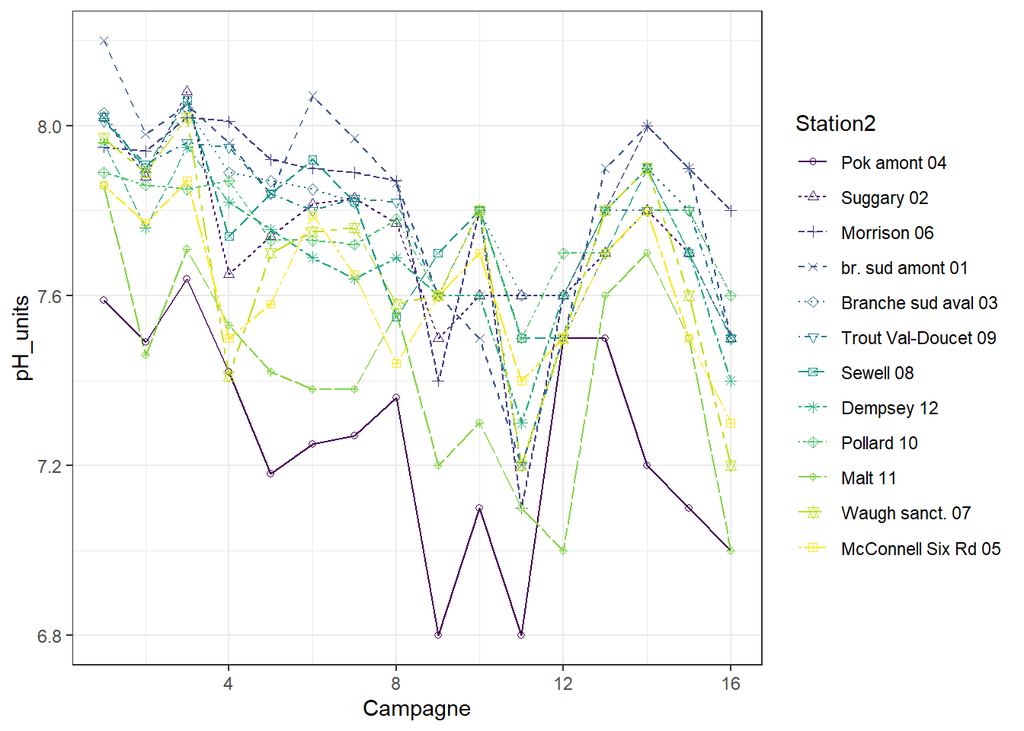

## Turbidité

### Turbidité variabilité spatiale

```
## [1] 192  86
```

```
## [1] 190  86
```

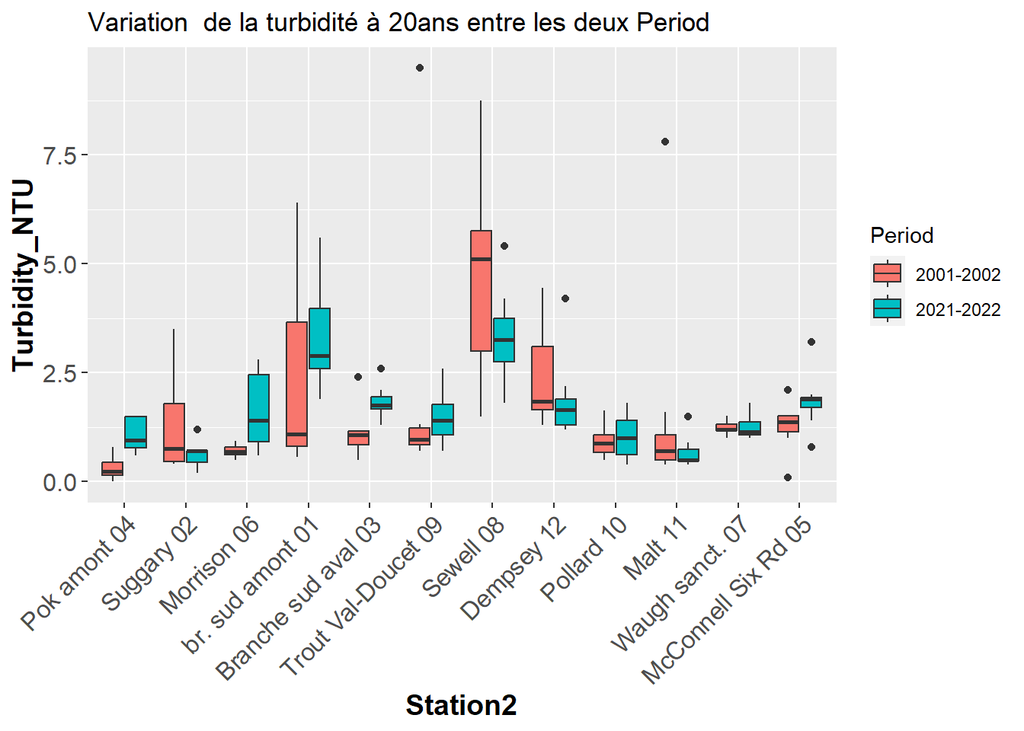

Commentaire:

Une médiane plus élevée indique une valeur de turbidité plus élevée.

La turbidité en 2021-2022 a une plus grande variabilité sur les stations 04, 06, 09, 10, et 07 par rapport à la turbidité 20en arrière.

La plus grande variabilité s’est observé sur les stations 08 et 01.

La turbidité présente très moins de variabilité des données sur la majorité des stations en 2001-2002 et 20ans après

Les moustaches au niveau de la station 08,02 et 12 en 2001-2002 et à la station 02 en 2021-2022 ce qui nous indique une grande variabilité dans les données.

Par rapport aux recommndations des normes cannadiennes en période d’écoulement limpide, l’augmentation induite de turbidité par rapport à la valeur de fond ne doit pas dépasser 8 NTU.

Dans le cas de notre rivière presque à tout les stations on est comprise entre cette valeur alors qu’au stat09 en 2001-2002 une valeur abbérente se retrouve au dela de cette valeur. Sur cette meme periode quelque station seraproche des 8 NTU.

La station 01 à la turbidité la plus élevé. En plus de la fin de l’été au premier septembre la turbidité était constante et compris entre 5 et 10 NTU. À l’automne du 1er septembre au 1er octobre la turbidité de l’eau a fortement augmenté (90%) et ensuite baissé aussi de 90% à la fin de l’automne. Au niveau de toutes les autres stations la turbidité à varié entre 0 et 10 NTU. La turbidité la plus élevé est de 44NTU.

Commentaire:

Commentaire:

### Autre manière de voir les variations saisonnières sur quatre années:

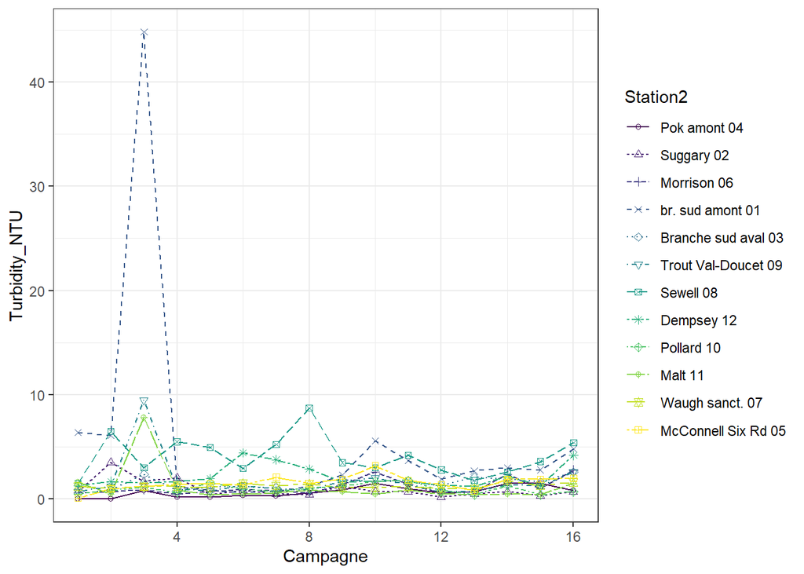

#### Supprimer points, méthode 1

Supprimer points déviants en créant un subset

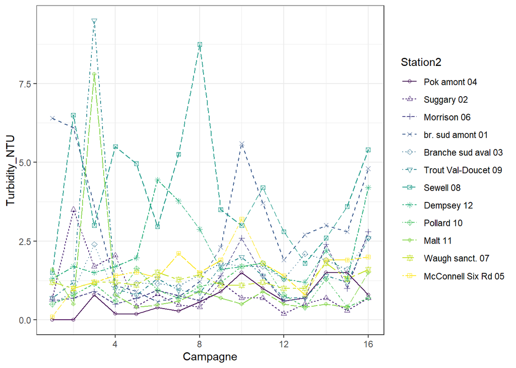

#### Supprimer points déviants, méthode 2

Supprimer points déviants en modifiant l’axe des Y

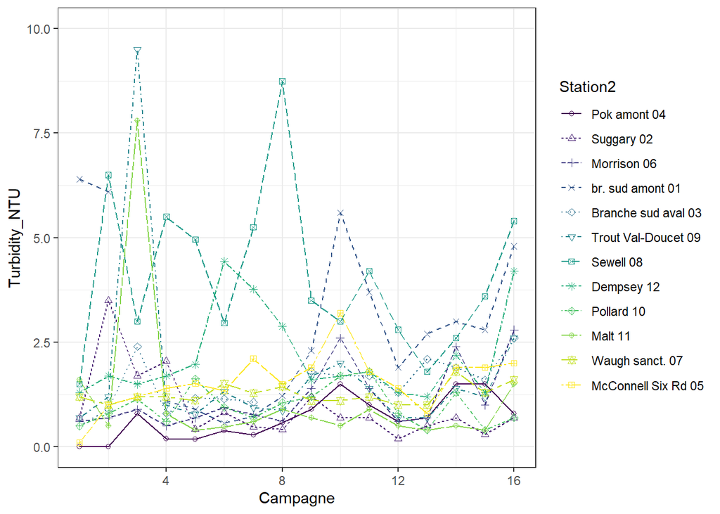

Commentaire du graphique des quatre années :

La turbidité de l’eau à la station 01 (Br sud amont) est très élevée, de 70% par rapport à la turbidité enregistrée durant toute la période 01 et 02 et ce sur toute les stations.

La station 08 présente une turbidité plus élevée durant les deux périodes que les autres stations.

La station 04 a la plus faible turbidité lors de la période 01 et la station 02 lors de la période 02.

Remarque :

## Couleur

### Couleur variabilité spatiale

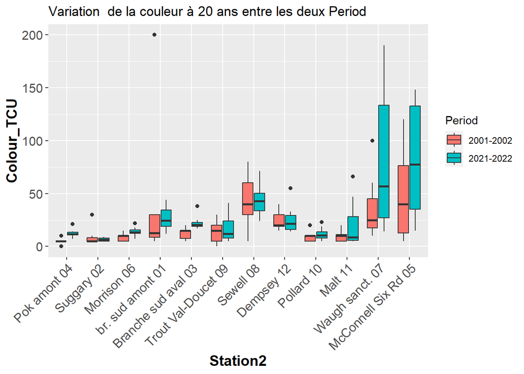

J’ai voulu exclu une valeur celle de la station 01 qui est plus éloigné en prennant moi de 190 mais je remarque que trois valeurs ont été exclu doc je peux dis que cette sendance est correcte. et ca n’a rien changer à l’allure de la des graphiques.

dim(Pok2001.2022) sub1cou=subset(Pok2001.2022, Colour_TCU<190) dim(sub1cou)

Commentaire:

La teneur de la couleur de l’eau augmente sur les stations graduellement de la station 04 jusqu’à la station 05.

La couleur au niveau des stations 05 et 07 sont très élevé 20ans après les couleurs obtenu en 2001-2002. A ces memes stations les données indique une très grande variabilité de la couleur.

La couleurs de l’eau a la station 08 indique une grande variabilité en 2001-2002 de plus qu’en 2021-2022.

On observe plus de valeur abbérentes sur les stations 04, 02, 01, 10 et 07 en 2001-2002 et aussi plus de valeur abbérentes sur les stations 04, 06, 03, 12, 10 et 11 en 2021-2022.

La plus grande valeur abbérentes est observé sur la station 01 en 2001-2002.

la teneur de la couleur varie entre 0 et 200 NTU.

Par rapport au recommandation des normes canadienne pour la qualité des eaux la couleur d’une eau naturelle est situé en dessous de 5mg/l pour les eaux très limpide et 1200 mg/l pour les eaux sombres et tourbeusess.

Dans le cas de notre rivière on peux qualifié la nature de cette eau de propre car elle présente une teneur sombre de 16,66% sur les stations 07 et 05 en 2021-2022 et une teneur de 6,25% sombre en 2001-2002.

Par rapport au autre station ont peut les qualifiés d’eau limpide

L’Eau en 2001-2002 est plus limpide qu’en 2021-2022.

Commentaire du graphique:

La couleur de l’eau est plus élevé à la station 01 et cela le premier octobre. les stations 05, 07 et 08 à la fin de l’automne en novembre on les teuneurs plus élevé. le reste des station.La couleur sur cette station varie entre 0 et 200, ou 09 stations varient entre 0 et 30 TCU.

Commentaire du graphique:

la station 02 à la plus faible teneur en couleur et tout les autres stations varient entre 0 et 30 TCU. Les station dont la teneur de la ccouleur à grandement varié sont les stations 12, 05, et 07. ces trois stations ont une teneur qui varient entre 20 et 80. la plus grande teneur est celle de la station 05, qui varie entre 80 et 75 TCU avec une grande baisse en septembre pour remonter en pique.

Commentaire du graphique:

Les plus grandes teneur en couleur sont les station 05 et 07 qui varient entre 0 et 180 TCU. La station 02 à la plus faible teneur en courleur. Les station 05 et 07 ont augmenté en pique en septembre jusqu’en octobre pour legerement baissé.

Commentaire du graphique:

Toujour la couleur lada station 05 et 07 ont les plus grande teneur en couleur. Elle ont aussi augmenté de septembre jusqu’en novembre. la station 08 aussi à legement augmenté d’aout jusqu’en novembre. la teneur a varié entre 0 et 150 TCU. la station 02 a toujour la plus faible teneur en couleur.

Commentaire:

La teneur en couleur la plus grande est celle de la station 01 en octobre 2001. durans la periodes 01 ce sont les stations 05,07 et 08 qui ont grandement varié. ces trois station on plus augmenté en 2001 qu’en 2002. en 2002 ils ont aussi augmenté mais moins qu’en 2002.

Commentaire:

Durant toutes la periodes 02 les stations 05 et 07 sont les plus élevé que tout les autre station et cela de septembre en octobre pour juste légerement baissé en novembre. En 2022 elles sont les plus qui ont augmenter mais moins qu’en 2021. la station 08 à augmenter continuellement de 2021 en 2022 mais un peu moin que les stations 05 et 07. (un phénomène en est surement la cause entre septembre et novembre de ces années à voir …)

### Autre manière de voir les variations saisonnières sur quatre années:

traiter la date comme “Campagne no” (voir la création de la variable

“Campagne” au début du script).

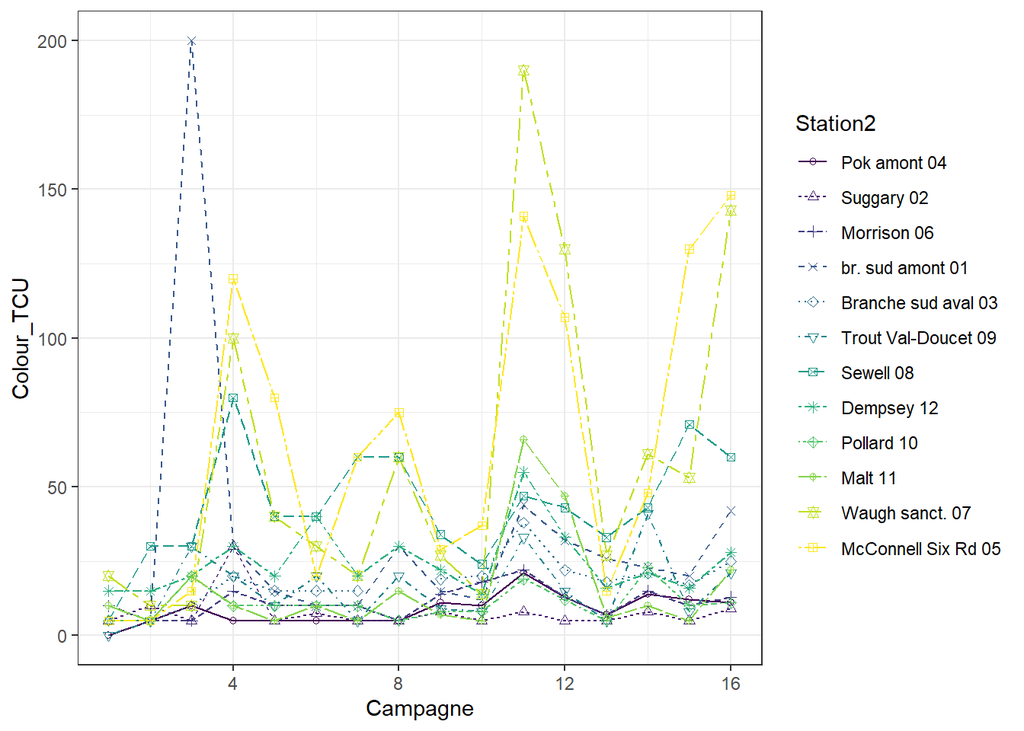

Commentaire du graphique des quatre années :

La couleur de l’eau est très élevée à la station 01 (Br sud amont) seulement en octobre 2001 et enregistre la couleur la plus élevée.

Les stations 05 (McConnell) et 07 (Waugh) ont aussi très fortement augmenté en novembre 2001, 2002. 20 ans après, elles ont encore plus augmenté, plus qu’en la période 01, et ce en octobre 2021 et en octobre et novembre 2022.

La couleur la plus faible est celle de la station 02 (Suggary).

Ce paramètre est marqué par des pics spécifique.

Question :

Qu’est-ce qui s’est passé sur les stations 05 et 07 en novembre 2001 et 2002 ? Encore plus, 20 ans plus tard en octobre 2021 et 2022 ? Qu’est-ce qui s’est passé en octobre 2001 sur la station 01 ?

Quel facteur affecte la couleur de l’eau sur ces stations en ces périodes ? Est-ce des territoires déboisés ?

Remarque :

La station 07 est une station aménagée, non loin d’une ferme de porc, cela peut agir sur la couleur de l’eau. La station 05, elle, est un peu au milieu d’un territoire déboisé non loin de l’autoroute et sur les berges on observe des débris et une pente du territoire converge l’eau vers cette station. La berge est remplie de petites plantes, mais à quoi cela est dû reste à savoir.

## Carbone organique dissous

### Carbone organique dissous variabilité spatiale

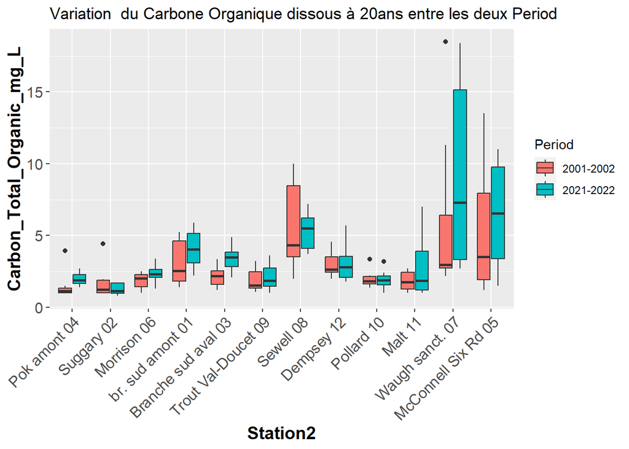

Commentaire:

La teneur en carbone organique dissous est faible en 2001-2002 qu’en 2021-2022.

La teneur en carbone organique dissous est plus élevé sur les stations 01, 08, 07 et 05 en 2021-2022 de plus que 20ans en arrière.

La teneur en COD indique une plus grande variabilité aux stations 01 et 08 en 2001-2002 de plus que 20ans plus tard.

alors ue sur les stations 11, 07 et 05 ils indique une plus grande variabilité en 2021-2022 que 20ans en arrière.

Des moustaches plus longues indiquent une plus grande variabilité dans les données.

Les moustaches m’indiquent une plus grande variabilité des données sur les stations 07, 05 dans les deux periodes et plus en 2001-2002 sur la station 08 et aussi plus sur la stations 12 et 11 en 2021-2021

Les valeurs abbérentes s’observe plus en 2001-2002 sur les stations 04, 02, 10 et 07 ce qui indique des anomaliess ou une variabilité extrême sur ces station à cette période.

Commentaire du graphique:

La teneur en CTO a continuellement augmenté de aout à novembre à a station 08. Les plus grande teneur ont été enregistré d’octobre en Novembre. La station 04 à la plus faible teneur en CTO sauf en octobre. la plus forte teneur est la station 07.

Commentaire du graphique:

La teneur en CTO à varié entre 0 et 12 mg/l et la plus forte teneur est enrégistré sur les stations 05, 07 et 08. Ces trois station on baisé de teneur d’aout en septembre et fortement augmenté (75%) de septembre jusqu’en novembre. Ces trois station sont à garder à l’oeil (meme chose pour la couleur). La station 02 et 04 a la plus faible teneur (lui aussi à garder à l’oeil meme chose avec la couleur). la plus forte teneur est la station 07.

Commentaire du graphique:

Comme au précedant la station 04 et 02 on les plus basse teneur en CTO. Et les plus élevé les stations 05 et 07. De Septembre en octobre ils ont augmenté en pique pour en suite légement baissé en novembre. La teneur en CTO varie ici entre 0 et 18 mg/l. la plus forte teneur est la station 07.

Commentaire du graphique:

La plus faibe teneur est celle de la station 02. les stations 05,07 et 08 ont les plus grande teneur en CTO et ont continuelement augmenté D’aout en novembre. la plus forte teneur est la station 07.

Commentaire:

EN periode 01 la teneur en CTO à augmenté plus en 2001 qu’en 2002. En 2001 la teneur à augmenté d’octobre en novembre. et en 2002 la teneur à augmenté de septembre en novembre. cela s’observe sur les stations 07, 05 et 08.

Commentaire:

Les plus grande teneur ont été observé sur les stations 07 et 05. en 2021 la teneur était plus élevé à la station 07 qu’en 2022. à la station 05 la teneur était plus élevé en 2022 qu’en 2021.Sur les deux station en 2021 la teneur est monté en pique de septembre en octobre pour légèrement baissé en novembre, mais en 2022 la teneur à augmenté d’aout en novembre.

```r
ggarrange(CTOg2001, CTOg2002, CTOg2021, CTOg2022, ncol=2, nrow=2)
```

[output not shown]

### Autre manière de voir les variations saisonnières sur quatre années:

traiter la date comme “Campagne no” (voir la création de la variable

“Campagne” au début du script).

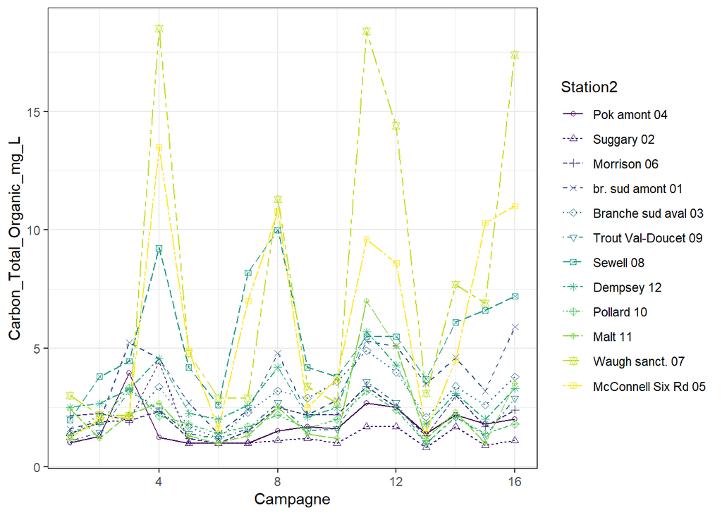

Commentaire du graphique des quatre années :

Conformément à la couleur de l’eau sur les stations 05 (McConnell), 07 (Waugh) et 08 (Sewell) en novembre 2001 et 2002, et octobre 2021 et novembre 2022, la concentration en carbone organique totale a aussi augmenté à ces périodes, et ce en pic.

Toutes les autres stations ont aussi augmenté à ces mêmes moments des périodes.

La station 02 (Suggary) a la plus faible teneur en COT (carbone organique totale) durant les deux périodes, et ce surtout lors de la deuxième période.

Ce paramètre est marqué par des pics.

Remarque :

Toutes les stations présentent une même tendance d’augmentation à ces dates, cela peut donc être dû à un phénomène territorial mais plus aux facteurs météorologiques ou climatiques à cause de la répétition de la même tendance sur toutes les stations.

## Contribution du carbone à la couleur

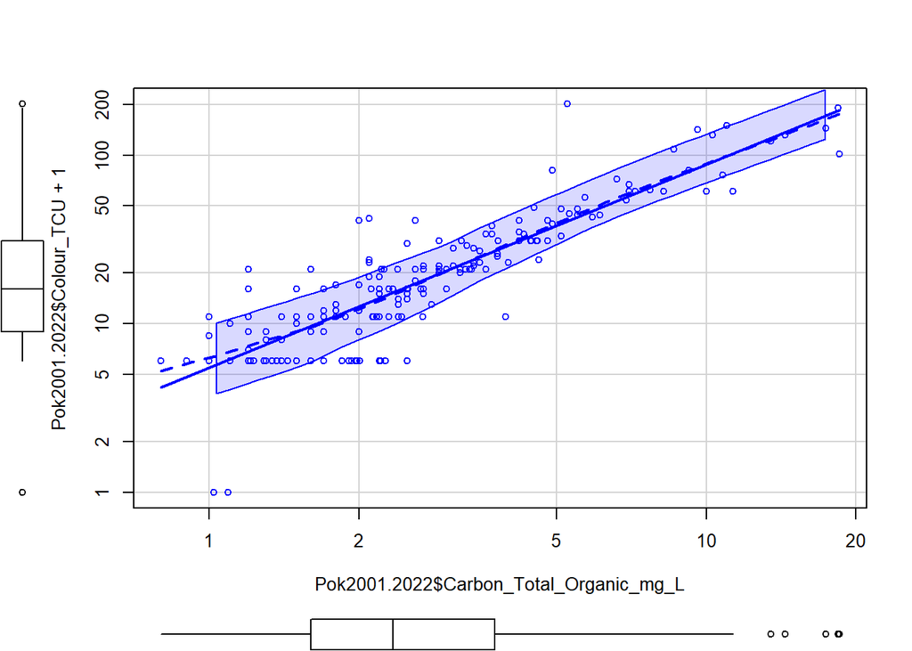

Couleur en fonction de la concentration de carbone organique pour les 12 stations et 16 dates d’échantillonnage

## E_coli

### E_coli variabilité spatiale

```
## [1] 191  86
```

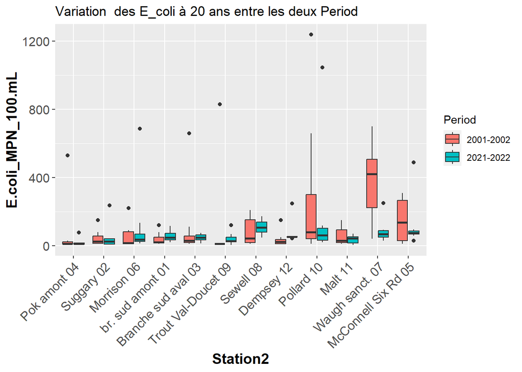

Commentaire:

La teneur en bacterie E_coli sont plus élevé uniquement sur les stations 10, 07 et 05 en 2001-2002 et ont une présence très négligeableen ces meme station en 2021-2022.

Les E_colis présente une tres grande variabilité sur la station 10, 07 et 05.

Des moustaches plus longues indiquent une plus grande variabilité dans les données.

les E_coli ont une longue variabilité trop élevé sur la station 10 et une longue variabilité élevé et faible sur la station 07.

Beaucoup de valeurs aberrantes peuvent indiquer des anomalies ou une variabilité extrême dans certaines stations ou périodes.

Les E_coli présentent beaucoup de valeurs abbérentes trops élevé prèsque sur tout les stations ce qui nous indique peut etre une anomalies ou une variabilité extrême dans autres station ou la concentration des E_coli sont tres élevé.

Commentaire du graphique:

Commentaire du graphique:

Commentaire du graphique:

La concentration des E_coli sont comprise entre 0 et 230mg/l. La plus grande concentration est cele de la station 02 qui a augmenté en pique en septembre pour avoir la valeur la plus élevé d’environs 235mg/l pour ensuite baisser jusqu’avoir la plus basse concentration en novembre. la plus basse concentration est celle de la station 04.

Commentaire du graphique:

La concentration des E_coli sont comprise entre 0 et 1050mg/l. La plus grande concentration est observé sur les station 10 et 06 en septembre. La station 10 à la plus forte concentration d’environ 1000mg/l à coté de la station 06 qui à environs mg/l. la concentration est faible sur tout les autres station mais en septembre ils ont tous variées.

Commentaire:

Commentaire:

Contriarement à la période précedent 2001-2002, la concentration cette periode à augmenté de 2021 en 2022. En 2021 En 2021 la concentration est comprise entre 0 et 250mg/l et cette augmentation est enregistré au début de la saison d’automne en septembre. en 2022 la concentration à quadiplé (comprise entre 0 et 1050mg/L) et cette augmentation s’est observé aussi au début de la saison d’automne en septembre.

```r
ggarrange(Ecolig2001, Ecolig2002, Ecolig2021, Ecolig2022, ncol=2, nrow=2)
```

[output not shown]

### Autre manière de voir les variations saisonnières sur quatre années:

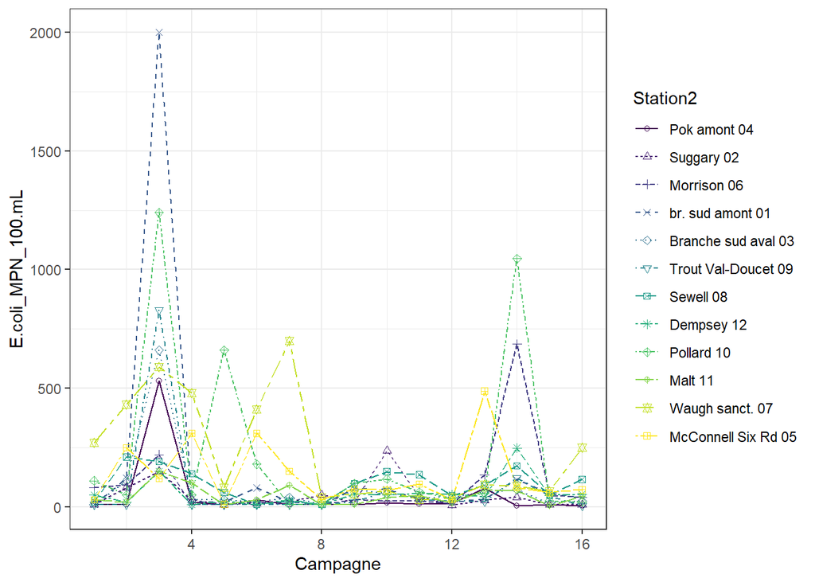

Commentaire du graphique des quatre années :

Les bactéries E_coli ont une concentration très élevée et en pic sur toutes les stations en octobre 2001.

En septembre 2022, on observe encore un pic de bactéries E_coli dans les eaux sur toutes les stations, mais en baisse de 50% par rapport à celle en 2001.

Le plus grand pic de bactéries est celui de la station 01 et 10.

Les stations 07 et 10 présentent les plus grands pics en 2002.

La concentration de l’eau en bactéries est très élevée en 2001 par rapport à la concentration en 2022, elle a baissé de 50%.

Remarque :

La station 07 a une porcherie pas loin d’elle ce qui peut etre à cause à son niveau mais les autres on dois creuser.

Question :

## Phosphore

### Phosphore variabilité spatiale

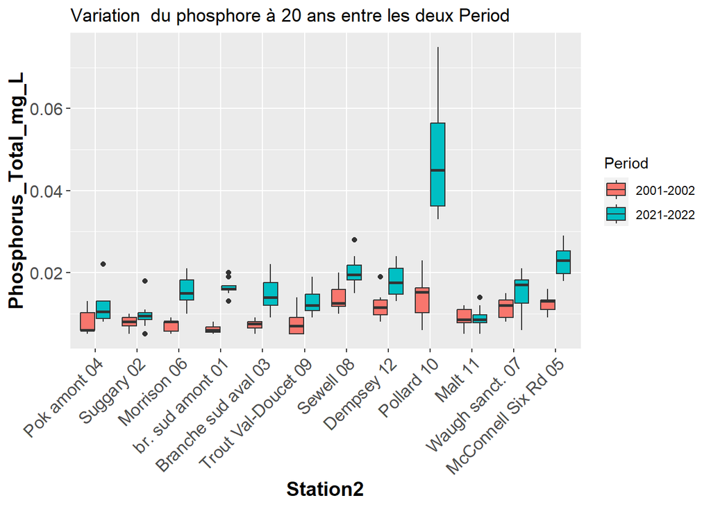

Commentaire:

le phosphore de la station 10 est extrêmement élevé à la deuxième période et ce plus que celle de toutes les autre stations.

Le phosphore à la plus grande variabilité sur la station 10 en 2021, plus grand de tout les deux période. Elle présente aussi une grande variabilité des données forte.

les données de la période 02 présente plus de valeur abbérente, et ce sur les station 04 0201 08 et 11.

Commentaire du graphique:

Le phosphore présente la plus grande valeur sur la station 12 en octobre et on on observe une penchant qui augmente sur prèsque tout les stations a cette meme date de la saison.

Commentaire du graphique:

Le phosphore de la station 10 et 08 sont les plus élevé à la fin de l’été en aout. Il varie entre 0,005 et 0,020 mg/l. Le phosphore sur tout les stations ont baissé d’aut en novembre.

Commentaire du graphique:

Le phosphore de la station 10 est la plus élevé de tout les stations de l’été en automne. Lest autres station n’ont pas vraiment varié.

Commentaire du graphique:

Le phosphore de la station 10 en cette années est aussi élevé que cette années que celle de toutes les autre stations et cela de l’été à l’automne.

le phosphore sur les autres stations sont prèsque identique

Commentaire:

Le phosphore de la période 01 à la plus haute et faible teneur en 2002. le phosphore à plus baissé en 2002 qu’en 2001.

Commentaire:

La station 10 sur toute la péeriode 02 à la plus grande teneur en phosphore. sur toute la période le phosphore de la station 10 à augmenté de aout en septembre et ensuite baissé jusqu.en novembre.

La station 02 présente une allure de la station la plus faible de toutes la période.

```r
ggarrange(Phosg2001, Phosg2002, Phosg2021, Phosg2022, ncol=2, nrow=2)
```

[output not shown]

### Autre manière de voir les variations saisonnières sur quatre années:

Traiter la date comme “Campagne no” (voir la création de la variable “Campagne” au début du script).

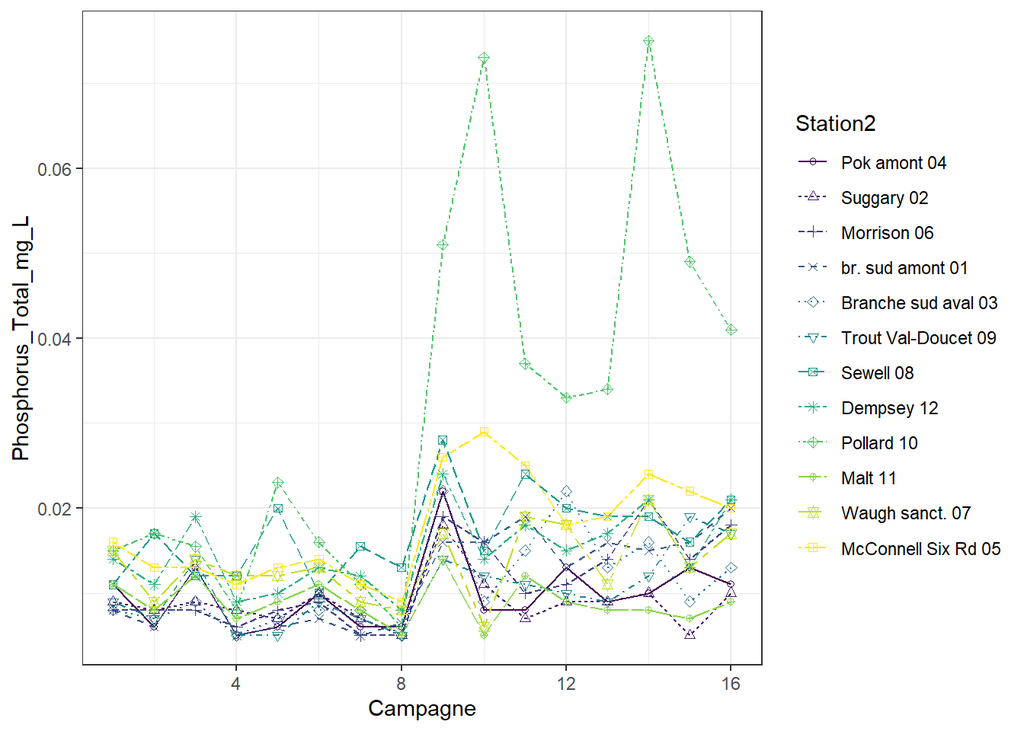

Commentaire du graphique des quatre années :

La teneur en phosphore a augmenté dans l’eau au niveau de la station 10 durant la période 02.

Le phosphore a augmenté en pic pendant la deuxième période sur la station 10 en septembre 2021 et en septembre 2022.

Toutes les autres stations ont augmenté de manière synchrone en octobre 2001 et encore plus en août 2021.

Question :

À quoi est due cette augmentation synchrone sur toutes les stations en ces dates ?

## Azote sous forme de nitrate (NO3-)

### Nitrate variabilité spatiale

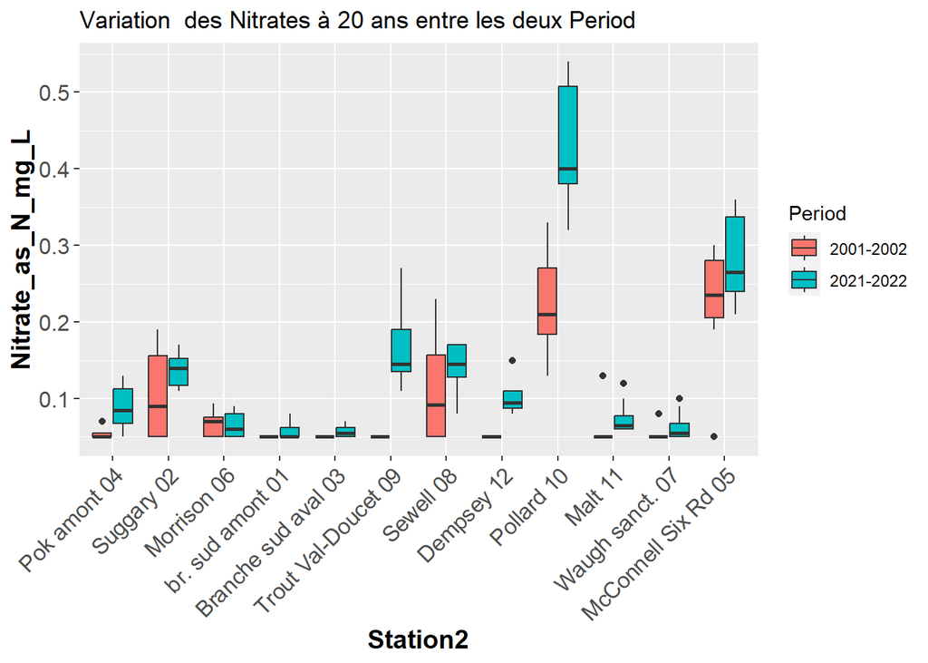

Commentaire:

La concentration de Nitrate est très élevé Sur la station 10 en 2021-2022 de plus qu’en 2001-2002.

Le nitrate de la station 10 et 05 est plus élevé que celle des autres stations.

Le nitrate présente une plus grande variabilité en 2001-2002 sur les stations 02 et 08 qu’en 20221-2022.

les plus grande variabilité sont observé en 2021-2022 sur les stations 10 et 05, et c’est les plus grandes variabilité de tous les périodes.

On observe une plus grande variabilité de données sur la station 10

Le nitrate présente plus de forte valeur abbérente sur les 12, 11, et 07 en 2021-2022

Commentaire du graphique:

Les station 10 et 05 ont les plus grande teneur en nitrate et on observe une grande baisse au niveau de la station 05 de septembre en novembre.

La plus basse teneur en nitrate est celle de la station 07.

Commentaire du graphique:

La station 07 à toujour la plus faible teneur en nitrate. Le nitrate de la station 10 baisse en pique d’aout en octobre pour legerement hausser en novembre.

Commentaire du graphique:

Le nitrate de la station 10 à la plus forte teneur d’aout en novembre. La station 05 était constatnt de aout en septembre et ensuite augmentéjusqu’en novembre. Le nitrate de la station 07 est toujour la plus faible.

Commentaire du graphique:

Le nitrate de la station 10 est la plus élevé et augment d’aout en novembre. Le station 05 est la deuxieme plus élevé et qui à légèrement baissé.

Commentaire:

Le nitrate a plus baisser en 2002 qu’en 2001 et la plus forte valeur est enrégistrer en 2002

Commentaire:

Le nitrate des station 10 et 05 sont les plus élevé de tous la période 2021-2022. Le nitrate en 2022 à plus augmenté qu’en 2021 sur la station 10.

Le nitrate sur la station 05 à augmenté en 2021 et à legerement baissé en 2022.

### Les 04 graph en un pour le nitrate

```r
ggarrange(Nitrateg2001, Nitrateg2002, Nitrateg2021, Nitrateg2022, ncol=2, nrow=2)
```

[output not shown]

### Autre manière de voir les variations saisonnières sur quatre années:

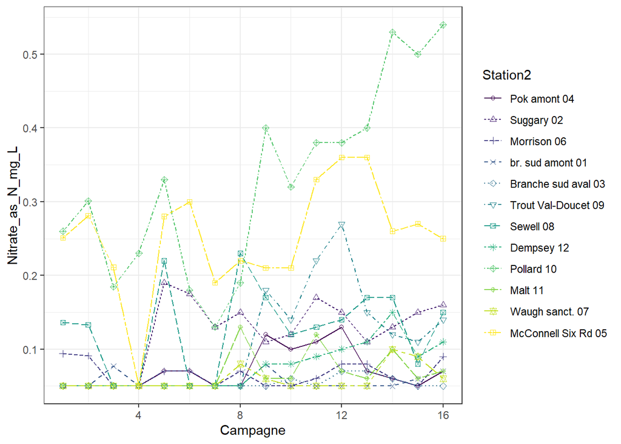

Commentaire du graphique des quatre années :

La concentration de nitrate est plus élevée dans la deuxième période des analyses que la concentration à la période 01 sur les stations 10 (Pollard) et 05 (McConnell).

La concentration la plus basse est celle à la station 07.

Les stations 05 et 10 sont un peu plus proches de l’autoroute, mais leurs berges sont très humides et sont des tourbières avec des plantes qui poussent aux alentours (je ne connais pas le nom des plantes, c’est pour cela que je ne les ai pas citées.

# RÉFÉRENCES

CGERP. 2003. “(Comité de Gestion Environnementale de La Rivière Pokemouche) Classification Provisoire Des Cours d’eaux Du Bassin Hydrographique de La Rivière Pokemouche.” Fonds en fiducie pour l’environnement du Nouveau-Brunswick.